# R Tutorial: basic diversity analyses using vegan

## Acknowledgements

Much of the material here is borrowed from material posted by Peter Clark, found [here](https://peat-clark.github.io/BIO381/veganTutorial.html).

## Getting started

I recommend you work through the following two tutorials prior to starting this tutorial:

- [**Introduction to R and RStudio**](https://people.ok.ubc.ca/jpither/00_Intro_R_RStudio/00_Intro_to_R.html)
- [**Reproducible work in R**](https://people.ok.ubc.ca/jpither/01_ReproducibleR/01_ReproducibleR.html)

### Start a new project

Once you have opened RStudio, you should always first create a new “project”, and in the process, create a new directory in which you’ll store all material.

You can find out more about projects at the RStudio website [here](https://support.rstudio.com/hc/en-us/articles/200526207-Using-Projects).

### Create an R Markdown document

R Markdown is a marukup language, which can render your text / scripts / graphs etc… to a variety of formats including HTML (webpages), PDF, and Word documents. More can be found in the [**Reproducible work in R](https://people.ok.ubc.ca/jpither/01_ReproducibleR/01_ReproducibleR.html) tutorial, but for now, simply select File > New file > R Markdown from the menu, then in the dialogue box enter a title, your name, and select HTML as your output format.

Now you need to name the Markdown document, so select File > Save as > yourfilename

### Load the required packages

In this tutorial we will make use of the following R packages:

- `vegan`
- `tigerstats` (this has some handy basic stats functions)
- `psych` (also has some handy functions)

`vegan` is the go-to package that provides the tools for conducting most of the main kinds of diversity analysis. There are many different `vegan` learning resources online that you can find via Google.

At the following [link](https://cran.r-project.org/web/packages/vegan/vignettes/diversity-vegan.pdf) you can find a PDF vignette for diversity analyses in `vegan` authored by Jari Oksanen.

Install the packages if you haven’t already:

```r
install.packages("vegan")
install.packages("tigerstats")
install.packages("psych")
```

Once installed, load the package as follows:

```r
library(vegan)
library(tigerstats)
library(psych)
```

### Explore data

Let’s look at the datasets available in the `vegan` package:

```r
data(package = "vegan")
```

These datasets are built in to the `vegan` package, and we’ll use some of them in this tutorial.

**TIP**: Sometimes you may wish to download datasets that are stored online somewhere. If you have a URL (web) address for these, you can use the `url` function in combination with the `read.csv` function as in the following example:

```r
country <- read.csv(url("https://people.ok.ubc.ca/jpither/datasets/country.csv"))
```

**TIP:** It is good practice to store all your data files as “comma-separated-value” or “CSV” files, as these are readily used by any data analysis software.

Now let’s load the `dune` dataset from the `vegan` package, and look at its structure:

```r
data(dune)  # this attaches the dataset
str(dune)
```

```
## 'data.frame':    20 obs. of  30 variables:
##  $ Achimill: num  1 3 0 0 2 2 2 0 0 4 ...
##  $ Agrostol: num  0 0 4 8 0 0 0 4 3 0 ...
##  $ Airaprae: num  0 0 0 0 0 0 0 0 0 0 ...
##  $ Alopgeni: num  0 2 7 2 0 0 0 5 3 0 ...
##  $ Anthodor: num  0 0 0 0 4 3 2 0 0 4 ...
##  $ Bellpere: num  0 3 2 2 2 0 0 0 0 2 ...
##  $ Bromhord: num  0 4 0 3 2 0 2 0 0 4 ...
##  $ Chenalbu: num  0 0 0 0 0 0 0 0 0 0 ...
##  $ Cirsarve: num  0 0 0 2 0 0 0 0 0 0 ...
##  $ Comapalu: num  0 0 0 0 0 0 0 0 0 0 ...
##  $ Eleopalu: num  0 0 0 0 0 0 0 4 0 0 ...
##  $ Elymrepe: num  4 4 4 4 4 0 0 0 6 0 ...
##  $ Empenigr: num  0 0 0 0 0 0 0 0 0 0 ...
##  $ Hyporadi: num  0 0 0 0 0 0 0 0 0 0 ...
```

[output cut: 16 more lines]

This shows there are 20 observations (cases, or rows) and 30 variables (columns).

In fact, this is a **site by species abundance matrix**, where each cell holds the abundance of the corresponding species (column) in the given site (row). This is the key input dataframe for diversity analyses.

## Calculating local diversity (alpha diversity)

First let’s simply enumerate the number of species in each of the 20 sites, thus quantifying *species richness*.

Let’s:

- calculate richness for the sites in the `dune` dataset
- assign the resulting 20 values to a dataframe (`dune.diversity`, initially with one variable), naming the variable “richness”
- generate a histogram of the resulting values to visualize the data

To calculate site richness, let’s first create a new site x species presence/absence matrix, by creating a new dataframe then replacing any non-zero values with 1.

```r
dune.presabs <- dune
dune.presabs[dune.presabs > 0] <- 1
```

We can now use the handy `rowSums` function to tally the number of species in each site (row):

```r
dune.diversity <- data.frame(richness = rowSums(dune.presabs))
```

Now the histogram:

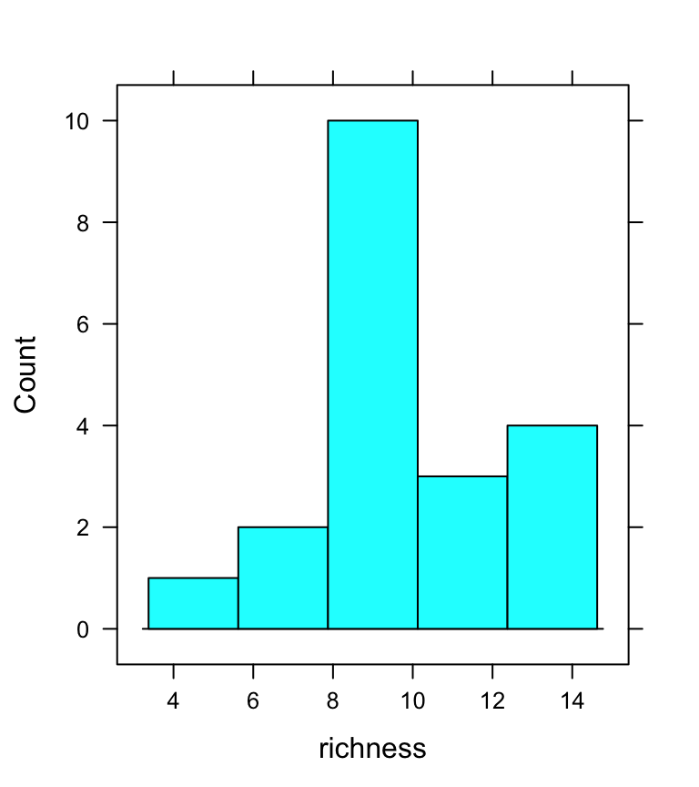

```r
histogram(~ richness, data = dune.diversity, type = "count")
```

Let’s now calculate diversity indices that take account of species’ abundances.

The `diversity` function in `vegan` calculates three such diversity indices: *shannon*, *simpson*, and *invsimpson* (inverse simpson).

```r
?diversity
```

First simpson, adding it to our dataframe:

```r
dune.diversity$simpson <- diversity(dune, index = "simpson")
```

Now shannon diversity:

```r
dune.diversity$shannon <- diversity(dune, index = "shannon")
```

Now let’s look at how each of the three measures relate to each other, using the `pairs.panels` function from the `psych` package, which provides a “scatterplot matrix”. We’ll add some arguments to tailor the figure:

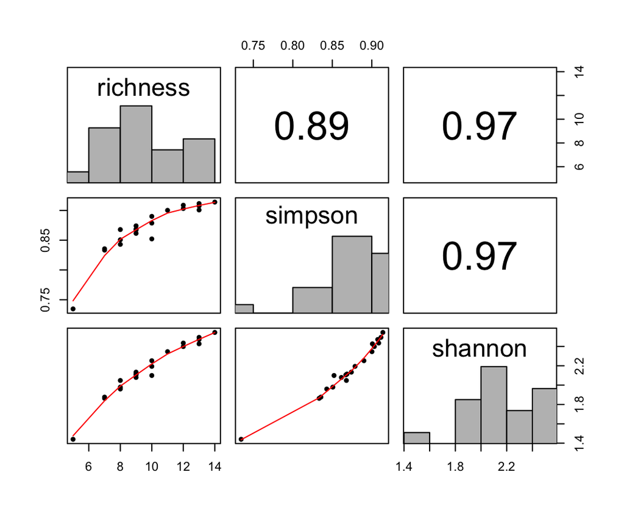

```r
pairs.panels(dune.diversity, density = F, ellipses = F, hist.col="grey", rug = F)
```

This not only shows the pairwise scatterplots, but also the Pearson correlation coefficient for each pairwise association, and a histogram for each variable.

## Rarefaction

There are myriad issues related to enumerating richness and especially *comparing* richness across samples. For an excellent primer, consult this PDF accessible [online](http://viceroy.eeb.uconn.edu/RKCPublications/GotelliAndColwellInMagurranAndMcGill_2011.pdf)

The more we look (the more effort we spend), the more species we’ll find. Unless we can be sure our sampling effort is identical among sites, we can just compare our raw richness values among those sites. Also, if species density differs among sites, then we have to be careful too.

The `vegan` packages provides tools for rarefying samples so they can be appropriately analyzed.

Use the `rarefy` function to give the *expected* species richness in random subsamples of size “sample” from the community:

```r
dune.diversity$rarefied.richness <- rarefy(dune, sample=12)
```

Let’s look at how this compares with raw richness:

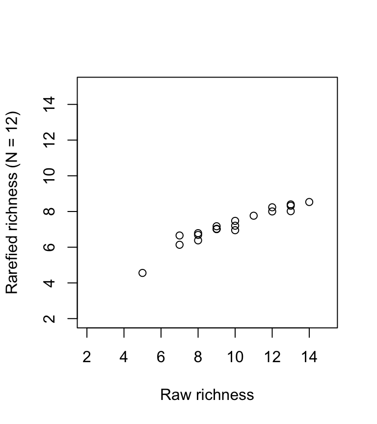

```r
plot(rarefied.richness~richness, data = dune.diversity, xlim = c(2, 15),
     ylim = c(2, 15), xlab = "Raw richness", ylab = "Rarefied richness (N = 12)")
```

Now let’s plot the **rarefaction** curves for the dune dataset:

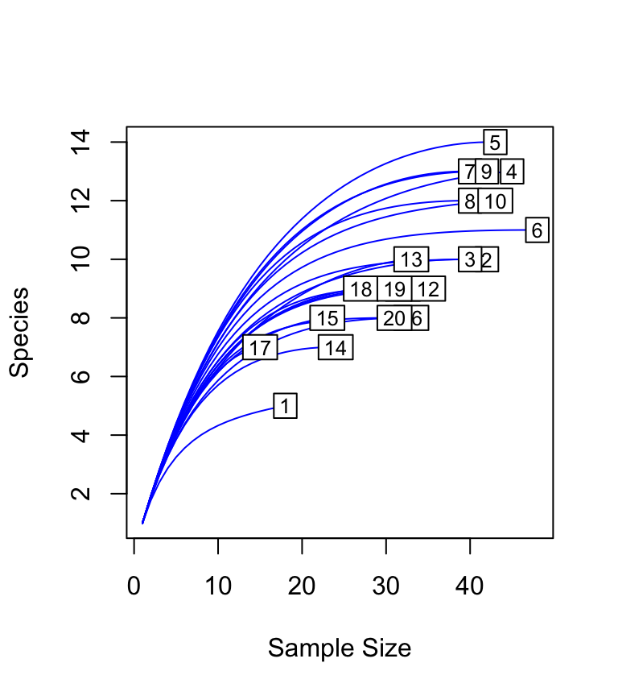

```r
rarecurve(dune, step = 1, col="blue")
```

Now let’s ask what the expected richness of each site is given a sample size of 10:

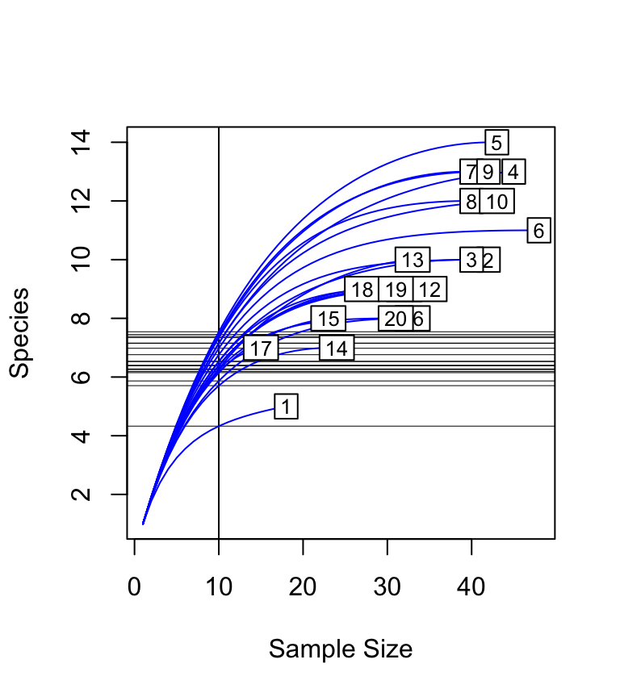

```r
rarecurve(dune, step = 1, sample = 10, col="blue")
```

## Quantifying differences in composition among sites (beta diversity)

There is an enormous literature on quantifying beta diversity. I recommend the following readings if you’re interested:

- [Anderson et al. (2010)](http://onlinelibrary.wiley.com/doi/10.1111/j.1461-0248.2010.01552.x/abstract)
- [Legendre (2014)](http://onlinelibrary.wiley.com/doi/10.1111/geb.12207/abstract)

The function `vegdist` calculates a variety of indices of difference in composition. Some of these are suited to presence/absence data, and others make use of abundances.

```r
?vegdist
```

Let’s first use the presence/absence matrix we created earlier to calculate pairwise Jaccard dissimilarities:

```r
dune.jaccard <- vegdist(dune.presabs, method = "jaccard")
```

Note that the resulting object is a special class of object called a “distance matrix”.

Now let’s use the original abundance matrix to calculate pairwise Bray-Curtis dissimilarities:

```r
dune.bray <- vegdist(dune, method = "bray")
```

Now let’s see how they relate to one-another with a scatterplot, adding a 1:1 line:

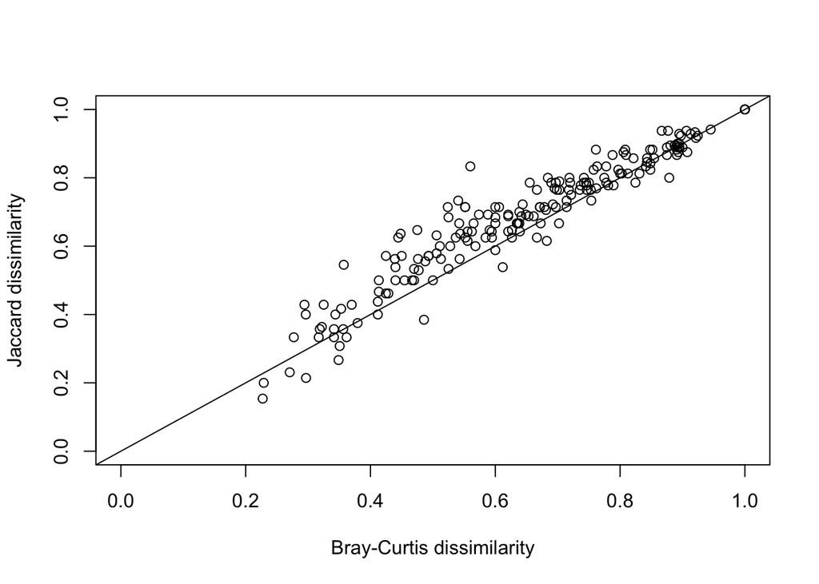

```r
plot(dune.bray, dune.jaccard, xlab = "Bray-Curtis dissimilarity",
     ylab = "Jaccard dissimilarity", xlim = c(0, 1), ylim = c(0, 1))
abline(0,1)
```

You can see for many of the pairwise site comparisons the Jaccard values are higher than the corresponding Bray-Curtis values.